[figure not shown]

# Base de données de services des citoyens

Projet de base de données

21 mai 2019

# Déscription du projet

## Introduction

Notre projet est une base de données à destination de citoyens et le cadre administratif d’un pays. Le but est de pouvoir répertorier et d’avoir accès aux différents papiers et informations relatifs à un citoyen donné et de pouvoir également faire les démarches en lignes afin d’obtenir des aides, des papiers ou autres, le tout sur la même plateforme.

Actuellement, les plateformes pour percevoir des aides, payer des impôts ou demander certains papiers ou justificatifs sont rarement les mêmes, ce qui peut compliquer les tâches des citoyens et des autorités, qui pourraient avoir besoin de certaines informations sur certains citoyens.

La base de données est adaptée pour deux applications web: l’une est mise à disposition des résidents dans un pays et l’autre pour le corps administratif qui traitera les demandes effectuées sur le premier site.

## Mise-à-jour

Après les retours que vous nous avez fait, nous avons modifié notre modèle et nous l’avons rendu plus concis et fonctionnel.

Le sujet abordé est très complexe, mais grâce à notre nouveau modèle, quelque soit la procédure qu’on souhaite effectuer elle se traduit à quelques requêtes simples.

# Conception

## Modèle Entité/Association

Après plusieurs discussions nous avons réussi à poser les bases de notre modèle avec les différentes utilisations possibles. Voici donc notre schéma Entité/Association final obtenu.

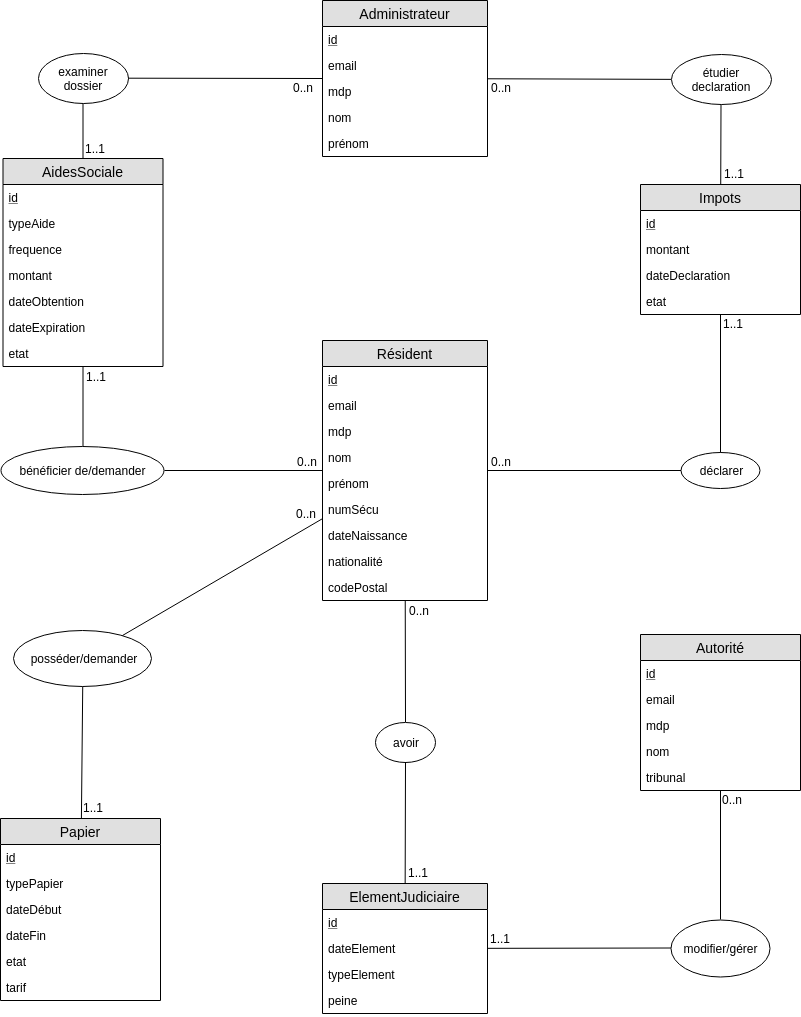

Modèle Entité/Association

### Résident

Le résident, comme on le voit sur le diagramme E/A, est le centre de cette application. Il doit pouvoir générer des justificatifs des différents papiers en sa possession (justificatifs de passeport, carte de séjour, carte d’identité, permis de conduire etc.) ainsi que des justificatifs des impôts qu’il auraient pu avoir déjà versé ainsi qu’un justificatif des aides sociales qu’il aurait pu avoir perçu. De plus il doit également être en mesure d’effectuer des démarches pour l’obtention de ces différents papiers et la régularisation de sa situation en faisant différentes déclarations lui permettant de payer ses impôts ou de percevoir des aides. Ainsi le résident peut par exemple effectuer une déclaration de ses revenus qui devra être validé par un administrateur afin qu’il puisse payer les impôts correspondant a sa situation, de même pour les aides sociales.

### Administrateur

L’administrateur a pour unique rôle de vérifier les déclarations faites par le résident. Les déclarations concernant ses revenus pour les impôts et les déclarations qu’il auraient effectué pour percevoir certaines bourses ou autres aides sociales.

### Autorité

Cette entité peut consulter les informations relatives aux habitants et compléter le casier judiciaire des habitants. Hormis le casier judiciaire des habitant, il ne peut rien modifier mais il a un droit de regard sur toutes les informations concernant les utilisateurs enregistrés en tant que résidents.

## Liens et entités

### Impôts et aides sociales

Un résident peut, tout d’abord, générer une preuve ou plusieurs preuves du payements passés de ses impôts, de plus il peut également faire une déclaration en remplissant un formulaire qui devrai être validé par un administrateur afin de pouvoir payer ses impôts. Pour établir une déclaration afin de payer des impôts il faut qu’un Résident remplisse un ou plusieurs formulaires correspondant chacun a un impôt précis (par exemple impôt sur le revenu ), formulaires qui devront être validé par un Administrateur pour que la déclaration existe ; Pour les aides sociales on retrouve exactement le même principe qu’avec les impôts pour comprendre cette partie il suffit donc se référer à l’explication ci-dessus

### Element judiciaire

Chaque résident possède un casier judiciaire (celui peut être vide ou non). Il peut consulter son casier judiciaire mais ne peut le modifier. Les autorités peuvent consulter le casier judiciaire de chaque résident (comme toutes les autres informations) mais peuvent également le compléter ci besoin en renseignant de nouvelles informations ou en supprimant certaines.

## Schéma relationnel

[figure not shown]

Diagramme du schéma relationnel

# Implémentation

## Initialisation de la base de donnée

Il s’agit de traduire le schéma relationnel en *MySQL*, voici le fichier `db/tables.sql` permettant de créer la base de données et ses relations.

```sql
DROP DATABASE IF EXISTS pays;
CREATE DATABASE pays;
USE pays;

CREATE TABLE Resident (
  id INTEGER NOT NULL AUTO_INCREMENT,
  email VARCHAR(255) NOT NULL,
  mdp VARCHAR(50) NOT NULL,
  nom VARCHAR(70) NOT NULL,
  prenom VARCHAR(35) NOT NULL,
  numSecu BIGINT(15),
  dateNaissance DATE NOT NULL,
  nationalite VARCHAR(90),
  codePostal VARCHAR(18),
  PRIMARY KEY (id)
);

CREATE TABLE Administrateur (
  id INTEGER NOT NULL AUTO_INCREMENT,
  email VARCHAR(255) NOT NULL,
  mdp VARCHAR(50) NOT NULL,
  nom VARCHAR(70) NOT NULL,
  prenom VARCHAR(35) NOT NULL,
  PRIMARY KEY (id)
);

CREATE TABLE Autorite (
  id INTEGER NOT NULL AUTO_INCREMENT,
  email VARCHAR(255) NOT NULL,
  mdp VARCHAR(50) NOT NULL,
  nom VARCHAR(70) NOT NULL,
  prenom VARCHAR(35) NOT NULL,
  tribunal VARCHAR(10),
  PRIMARY KEY (id)
);

CREATE TABLE Papier (
  id INTEGER NOT NULL AUTO_INCREMENT,
  typePapier VARCHAR(50),
  dateDebut DATE,
  dateFin DATE,
  etat VARCHAR(20),
  tarif INTEGER,
  idResident INTEGER NOT NULL,
  PRIMARY KEY (id),
  FOREIGN KEY (idResident) REFERENCES Resident(id)
);

CREATE TABLE AideSociale (
  id INTEGER NOT NULL AUTO_INCREMENT,
  typeAide VARCHAR(70) NOT NULL,
  frequence VARCHAR(10),
  montant INT,
  dateObtention DATE,
  dateExpiration DATE,
  etat VARCHAR(20),
  idResident INTEGER NOT NULL,
  idAdmin INTEGER,
  PRIMARY KEY (id),
  FOREIGN KEY (idResident) REFERENCES Resident(id),
  FOREIGN KEY (idAdmin) REFERENCES Administrateur(id)
);

CREATE TABLE Impots (
  id INTEGER NOT NULL AUTO_INCREMENT,
  montant INT,
  dateDeclaration DATE,
  etat VARCHAR(20),
  idResident INTEGER NOT NULL,
  idAdmin INTEGER,
  PRIMARY KEY (id),
  FOREIGN KEY (idResident) REFERENCES Resident(id),
  FOREIGN KEY (idAdmin) REFERENCES Administrateur(id)
);

CREATE TABLE ElementJudiciaire (
  id INTEGER NOT NULL AUTO_INCREMENT,
  dateElement DATE,
  typeElement VARCHAR(10),
  peine VARCHAR(20),
  idResident INTEGER NOT NULL,
  idAuthorite INTEGER NOT NULL,
  PRIMARY KEY (id),
  FOREIGN KEY (idResident) REFERENCES Resident(id),
  FOREIGN KEY (idAuthorite) REFERENCES Autorite(id)
);
```

Ensuite, nous avons écrit des scripts (en *python* cf. `db/data`) permettant de générer des données aléatoires mais assez pertinentes afin de pouvoir tester nos requêtes et d’avoir un aperçu de l’application du projet.

Après avoir populé la base de données, nous avons sauvegardé les données dans des scripts MySQL sous forme de `INSERT` pour des raisons de portabilité (cf. `db/populate`).

## Environnement

Ce rapport a été écrit en *r markdown* et ensuite traduit en LaTeX et HTML à l’aide de *knitr* et *pandoc*. Cela pour dire qu’à partir de ce point, le code dans ce rapport a été interprété par *knitr* qui rajoute ensuite les résultats obtenus au rapport. Le code source est disponible sur le répértoire github github.com/minikara/bdd-pays.

De plus, nous avons limité les résultats affichés dans le PDF (pour des raisons de visibilité) donc nous recommandons la lecture de cette partie sous sa forme HTML sur minikara.github.io/bdd-pays car les résultats sont complets et plus lisibles.

Commeçons alors par l’établissemnt de la connection avec la base de donnée à l’aide de la librairie R `DBI`

```r
library(DBI)
pays <- dbConnect(RMySQL::MySQL(), dbname="pays", username="root")
```

## Visualisation des relations

```sql
SELECT * FROM Resident;
```

| id | email | mdp | nom | prenom | numSecu | dateNaissance | nationalite | codePostal |
| --- | --- | --- | --- | --- | --- | --- | --- | --- |
| 1 | Sed.congue.elit@in.ca | FFO07WWH5BF | Caron | Maëlle | 1.668100e+12 | 1944-06-19 | France | 3117 |
| 2 | Aenean@quisdiamPellentesque.edu | ZTP06XOJ5CW | Herve | Kimberley | 1.697052e+12 | 2017-04-10 | France | 21909 |
| 3 | molestie@AliquamnislNulla.com | SXH35ZVE0LR | Pons | Quentin | 1.600022e+12 | 1992-05-23 | France | 12444 |
| 4 | sollicitudin.commodo.ipsum@Duis.com | TFQ15CRR3TU | Lemoine | Maïlé | 1.677051e+12 | 1992-07-18 | France | 16092 |
| 5 | lobortis.mauris.Suspendisse@mauriserateget.org | SXK69NYT4QB | Julien | Éloïse | 1.602012e+12 | 2004-11-20 | France | X2S 3T0 |
| 6 | consequat@Aliquamvulputateullamcorper.com | CQY08SAS5UV | Le gall | Simon | 1.629111e+12 | 1939-06-27 | France | 66121 |
| 7 | enim@dolor.com | JBC62RLA0XZ | Daniel | Cédric | 1.694102e+12 | 1951-06-26 | Northern Mariana Islands | 26098 |
| 8 | eget@scelerisqueduiSuspendisse.ca | WJE08HZV4OG | Guillot | Adam | 1.681053e+12 | 1957-05-27 | France | 912415 |
| 9 | tortor@metus.net | SIB74QPV6XS | Renard | Yanis | 1.635022e+12 | 1979-12-22 | France | 486292 |
| 10 | ut@nec.ca | KHY48ULC8IN | Menard | Yasmine | 1.681091e+12 | 1956-01-03 | France | 81353 |
| 11 | ac.orci.Ut@Cras.ca | BRW37RHT8OK | Roussel | Corentin | 1.643111e+12 | 1991-12-13 | France | P0L 8A1 |
| 12 | hendrerit.id.ante@gravida.ca | GRG43DQC2OE | Marchand | Félix | 1.676022e+12 | 2018-05-29 | Slovenia | 63377 |
| 13 | parturient.montes.nascetur@eu.co.uk | BKB25ZBS8UQ | Gauthier | Gabin | 1.628033e+12 | 1954-05-08 | France | 40-152 |
| 14 | dignissim.tempor@tellusPhasellus.org | JYL63MPH8OQ | Gonzalez | Robin | 1.690121e+12 | 1979-11-07 | France | 01315-619 |
| 15 | Donec.sollicitudin@consequatdolor.net | DOY46FVH0GG | Brunet | Jade | 1.670101e+12 | 1959-08-11 | Venezuela | 58871 |
| 16 | scelerisque.mollis.Phasellus@Phasellusataugue.com | IKW42MEI0TU | Francois | Gaspard | 1.672020e+12 | 1959-01-07 | France | 5091 PD |
| 17 | dis@Curabituregestasnunc.ca | EED22LWZ7KH | Gautier | Salomé | 1.613112e+12 | 1962-04-17 | France | 7998 |
| 18 | pharetra.ut.pharetra@sociisnatoque.co.uk | TON13YHZ4TO | Clement | Kilian | 1.677062e+12 | 2005-05-02 | France | 2588 |
| 19 | ornare.In@eleifendnunc.edu | VTS30RZM8BM | Lefebvre | Alexia | 1.666021e+12 | 1999-10-05 | Åland Islands | 50606 |
| 20 | Phasellus.vitae@aliquamiaculis.edu | TPD40OAY0MX | Henry | Dorian | 1.643011e+12 | 1932-10-12 | France | 60885-926 |
| 21 | metus.In.lorem@Cum.edu | LIJ55MEG6EK | Noel | Loane | 1.618062e+12 | 1970-10-09 | Holy See (Vatican City State) | 4968 EQ |
| 22 | dignissim@purussapien.ca | CYW72KEO3XO | Prevost | Anaël | 1.645111e+12 | 1943-03-15 | France | R6C 9G7 |
| 23 | et.magnis@lorem.edu | QZN50SDS4OA | Bouvier | Maxence | 1.627042e+12 | 1974-12-08 | France | 3578 NY |
| 24 | massa@Cras.org | SWT16KVS9DP | Leclerc | Félix | 1.687100e+12 | 2005-06-12 | France | 98501 |
| 25 | Duis@maurisSuspendisse.org | XAF34PEM4TK | Millet | Nolan | 1.654101e+12 | 1928-06-08 | France | 6009 |
| 26 | elit.pharetra@Aeneaneget.org | QEL53ESM3HL | Huet | Jeanne | 1.646030e+12 | 1992-06-11 | France | 4137 OZ |
| 27 | risus.at.fringilla@adipiscing.edu | BQK30ICH8ZJ | Lucas | Gabin | 1.616091e+12 | 1932-08-22 | France | Y3X 7J3 |
| 28 | gravida.sagittis.Duis@torquentperconubia.net | POC31MVO0IR | Marechal | Émile | 1.663031e+12 | 2008-05-10 | France | 94149 |
| 29 | ut@eutellus.com | AJX84YMA3NI | Boucher | Diego | 1.691052e+12 | 1985-06-12 | Åland Islands | 83889-718 |
| 30 | cursus.et.eros@volutpat.edu | SRY37BKT3YF | Garnier | Lisa | 1.643071e+12 | 1959-09-01 | France | 4041 |

[output cut: 70 more lines]

```sql
SELECT * FROM Administrateur;
```

| id | email | mdp | nom | prenom |
| --- | --- | --- | --- | --- |
| 1 | auctor@turpisvitaepurus.org | YQP03FRH8QX | Charpentier | Maéva |
| 2 | hendrerit.id.ante@arcu.org | NEG98YKV3HR | Martinez | Bienvenue |
| 3 | nunc.Quisque.ornare@pharetra.org | RUE79QBN8LF | Nicolas | Noë |
| 4 | enim@mollisduiin.com | GLO71RVC5BG | Dumont | Renaud |
| 5 | fames.ac@enim.co.uk | VHR96VIN2WV | Gay | Syrine |
| 6 | ipsum@sed.net | QJH37JLU0TJ | Girard | Hugo |
| 7 | ultrices.posuere@magnaaneque.org | FLX93PDJ6SS | Marchand | Louis |
| 8 | magna@tempus.com | SAI78XKA3JT | Meyer | Alexandre |
| 9 | Suspendisse.ac@MorbivehiculaPellentesque.net | INV45QMG2HF | Deschamps | Justine |
| 10 | Donec.est.mauris@tinciduntpedeac.co.uk | KIW18CZB1UC | Marchand | Timéo |
| 11 | eu.sem.Pellentesque@eget.net | QSM21RGU5BL | Roux | Jeanne |
| 12 | dictum.placerat.augue@vitaeerat.ca | MZR63IMM8YX | Pereira | Jade |
| 13 | Quisque.libero.lacus@gravidasagittisDuis.ca | CMW89PEW3AR | Royer | Clémence |
| 14 | ante@auguescelerisquemollis.edu | TRZ62GVI0VL | Rousseau | Antonin |
| 15 | augue.porttitor.interdum@parturientmontesnascetur.edu | BFS90QIQ8CO | Nguyen | Louise |
| 16 | ante.lectus.convallis@CurabiturdictumPhasellus.ca | VPY35XRF9ZO | Dupont | Tatiana |
| 17 | eu.eleifend@nullaDonecnon.edu | VCB62FJJ7DB | Simon | Marine |
| 18 | enim.Nunc.ut@mi.ca | ZHL29TYM3ZF | Guyot | Gilbert |
| 19 | cursus.et@maurisid.edu | FXM39DEZ0JJ | Remy | Lorenzo |
| 20 | senectus.et.netus@commodotinciduntnibh.net | QNO57JNI9VE | Paul | Lilou |
| 21 | odio@ametante.edu | EFO81NVJ0RT | Roger | Justine |
| 22 | cursus.vestibulum.Mauris@dictumPhasellus.co.uk | MIU04VMT1JC | Gauthier | Paul |
| 23 | neque@Aliquamerat.edu | LMO08PAJ4WC | Collin | Yanis |
| 24 | tempus.mauris@aarcuSed.edu | GOU10PJC7MR | Herve | Chaïma |
| 25 | fames.ac@dignissimtempor.ca | ANC81ITL9OC | Dumas | Carla |
| 26 | arcu@sitametdapibus.ca | XNE62EPQ1BH | Pierre | Elsa |
| 27 | ultrices.posuere.cubilia@amet.com | XVH51QPK0TS | Brunet | Anaëlle |
| 28 | a.feugiat@enimnisl.ca | VJV75AJY3WN | Joly | Timéo |
| 29 | vitae.orci.Phasellus@bibendum.com | ALU19EAC0QK | Moulin | Malik |
| 30 | diam@eu.net | OHI81JPV9QN | Bonnet | Malik |
| 31 | ullamcorper.Duis@velitegestaslacinia.com | MIR96QWT4RQ | Masson | Sara |
| 32 | Sed.molestie@rutrum.org | YZR41LGA3SL | Bailly | Mélanie |
| 33 | et.netus.et@Nunclectuspede.net | VDY10BRG0PY | Renault | Amine |
| 34 | euismod.enim.Etiam@massaQuisque.com | MGX85VFX1IE | Chevalier | Juliette |
| 35 | risus.at.fringilla@hendrerit.ca | EOI44FGY3AU | Bourgeois | Gaspard |
| 36 | Nullam.velit.dui@aliquameu.edu | QFY34KNI2IF | Boyer | Maéva |
| 37 | elit@pedeNuncsed.ca | QRX18UYO7XS | Carre | Gabriel |
| 38 | ullamcorper.Duis.cursus@purusinmolestie.co.uk | KMX22ZCU0ZD | Dupuy | Esteban |
| 39 | Nunc.mauris.sapien@dictumPhasellusin.net | YBP54YXQ6AU | Renault | Lauriane |
| 40 | Aliquam.erat.volutpat@asollicitudinorci.edu | CLC05YLP1WB | Gauthier | Amine |
| 41 | auctor.Mauris.vel@cursuspurus.co.uk | QGY66GYK6VP | David | Thibault |
| 42 | cursus.purus@congue.ca | EXJ31GVC7NN | Dupuis | Lilou |
| 43 | justo.Proin@cursuseteros.edu | MWZ89UYV9MM | Albert | Lamia |
| 44 | semper.pretium.neque@mollisDuis.edu | VOF34NPX7GK | Louis | Catherine |
| 45 | malesuada@vitae.net | KOR76BAN7NE | Philippe | Clémence |
| 46 | pede.Cras@adlitora.com | OWE80PRD8WX | Boulanger | Louna |
| 47 | nonummy.ac.feugiat@ipsum.edu | IIY44RBE1RB | Nicolas | Arthur |
| 48 | tincidunt.nibh@pede.org | BIP28NME0AW | Jacquet | Adam |
| 49 | mauris.Integer@erat.ca | DSC50ORO9FW | Laine | Élise |
| 50 | velit.Pellentesque.ultricies@portaelita.co.uk | YKP56GWS5EE | Adam | Esteban |

```sql
SELECT * FROM Autorite;
```

| id | email | mdp | nom | prenom | tribunal |
| --- | --- | --- | --- | --- | --- |
| 1 | sem@cursusin.edu | RKR16WOX2ZF | Roche | Pauline | null |
| 2 | orci@tinciduntaliquam.net | CEF98OTV6ST | Petit | Dimitri | null |
| 3 | eget@acturpisegestas.ca | ZGJ79LWH4WC | Dubois | Florian | null |
| 4 | mi.enim.condimentum@ut.com | IVH25XVA8DJ | Fabre | Esteban | null |
| 5 | congue@eget.ca | VIE14CVG3FD | Renard | Bienvenue | null |
| 6 | Aliquam.auctor.velit@sagittislobortismauris.edu | VBR38YEI8AH | Rodriguez | Nathan | null |
| 7 | libero.Morbi.accumsan@augue.net | PJV75HCA5JF | Martinez | Émilie | null |
| 8 | pulvinar.arcu.et@eratvolutpatNulla.ca | HED17XOK1VA | Guyot | Marine | null |
| 9 | dignissim@diamatpretium.co.uk | ESP85TTI8LD | Francois | Loane | null |
| 10 | mus.Proin.vel@arcuVestibulumut.edu | DXM42IZZ6AN | Aubry | Maïlé | null |
| 11 | dui@tacitisociosquad.co.uk | FQB71SBX2FH | Bailly | Catherine | null |
| 12 | neque@Aliquam.ca | WAU78KZO9PY | Meyer | Killian | null |
| 13 | montes.nascetur@etultrices.edu | FPA06KMH7ZE | Lebrun | Samuel | null |
| 14 | euismod@aliquet.net | OVG14FLL4VZ | Leroux | Lamia | null |
| 15 | natoque@elitdictumeu.com | EJQ80RZX3WE | Meyer | Adrien | null |
| 16 | eget.venenatis.a@nullaIntincidunt.com | QQS01AAS7DV | Garnier | Florentin | null |
| 17 | adipiscing.lacus.Ut@ultricesDuisvolutpat.net | MGT51NEF5GI | Dubois | Émilie | null |
| 18 | massa.Quisque@enimnectempus.net | ASF53TRH0PV | Dubois | Jade | null |
| 19 | sodales@magna.com | RID84SUD1JD | Michel | Maxime | null |
| 20 | Morbi@purusNullamscelerisque.co.uk | FWQ32FIR1TU | Gauthier | Lou | null |
| 21 | Nunc.mauris@posuerecubiliaCurae.ca | THC91NZZ9CL | Sanchez | Maéva | null |
| 22 | nec.imperdiet.nec@justo.net | GEN44VYY2HD | Robin | Bienvenue | null |
| 23 | pede@Fuscemilorem.ca | IJN89VCN7CY | Renaud | Kylian | null |
| 24 | aliquet.Proin.velit@vellectusCum.ca | DWB58USM9QG | Le gall | Léo | null |
| 25 | mauris.sagittis@fringillaporttitorvulputate.co.uk | TPV18IBF9NM | Royer | Léa | null |
| 26 | nunc.nulla.vulputate@aliquamerosturpis.com | DNU62SVZ2VF | Berger | Thomas | null |
| 27 | Nunc@amet.net | BHH16BIE2JB | Jacob | Ambre | null |
| 28 | vel.sapien@tinciduntduiaugue.ca | CEU50EHX9NU | Bouvier | Lina | null |
| 29 | ornare.facilisis.eget@aliquet.com | GHU08AIG1ZT | Petit | Lily | null |
| 30 | Cum.sociis@ultricies.com | QQK32VBG2NM | Boucher | Agathe | null |
| 31 | dignissim@egetvenenatisa.edu | GIC22DIB4ER | Thomas | Françoise | null |
| 32 | justo.nec.ante@feugiat.net | NCR55KUD7JG | Philippe | Hugo | null |
| 33 | vestibulum@diamdictum.net | PYK32YZY1NC | Rey | Lola | null |
| 34 | Nunc.lectus@cursusaenim.edu | XFJ44LEM5LT | Meyer | Lamia | null |
| 35 | arcu.Vivamus@Maecenasiaculisaliquet.edu | FJE83GKV7GB | Fournier | Syrine | null |
| 36 | Curae@mollis.com | YUW88JEO0NE | Muller | Erwan | null |
| 37 | blandit@velit.ca | DYL92NUD9NY | Joly | Dylan | null |
| 38 | diam.dictum.sapien@fringillaporttitorvulputate.co.uk | AOW77NIP6AV | Prevost | Kylian | null |
| 39 | lectus.pede.et@euismodacfermentum.ca | FDR10XNH1YD | Leroux | Clara | null |
| 40 | consectetuer@pedePraesenteu.org | KCE47WIQ6RL | Baron | Loevan | null |
| 41 | eu@semper.ca | VSY64YMJ5WI | Fontaine | Margaux | null |
| 42 | sociis.natoque.penatibus@tristiqueac.ca | ZVQ74PUB5JY | Louis | Alexia | null |
| 43 | egestas@acmattisornare.ca | MCZ26FKH0KJ | Arnaud | Lola | null |
| 44 | dis.parturient.montes@Class.org | ALM28DXP4CK | Fontaine | Kilian | null |
| 45 | mi.lacinia@vestibulum.org | QIH79EHM8IY | Laine | Kimberley | null |
| 46 | sed.turpis@vitae.org | FEQ38AKB1TV | Durand | Mathieu | null |
| 47 | Integer.eu@fringillaeuismod.com | RLN25HDQ0MA | Barbier | Romane | null |
| 48 | auctor.odio.a@bibendum.co.uk | ZMU19UKQ2UW | Etienne | Lucas | null |
| 49 | malesuada.malesuada.Integer@semvitae.net | JDD33OSE2IY | Morin | Aaron | null |
| 50 | cursus.non.egestas@nibhenimgravida.edu | RUP53CPA8NA | Andre | Hugo | null |

```sql
SELECT * FROM AideSociale;
```

| id | typeAide | frequence | montant | dateObtention | dateExpiration | etat | idResident | idAdmin |
| --- | --- | --- | --- | --- | --- | --- | --- | --- |
| 1 | RSA | m | 246 | 2017-03-05 | 2018-02-28 | Expire | 90 | 41 |
| 2 | PrimeNaissance | p | 562 | 2017-04-14 | 2017-04-14 | Expire | 18 | 35 |
| 3 | CMU | a | 302 | 2016-08-08 | 2017-08-03 | Expire | 72 | 41 |
| 4 | CMU | a | 401 | 2015-08-09 | 2016-08-03 | Expire | 36 | 50 |
| 5 | RSA | m | 284 | 2016-03-24 | 2017-03-19 | Expire | 60 | 44 |
| 6 | CROUS | m | 402 | 2017-08-06 | 2018-08-01 | Expire | 22 | 50 |
| 7 | CAF | m | 62 | 2011-04-28 | 2012-04-22 | Expire | 59 | 26 |
| 8 | CAF | m | null | 2019-02-22 | null | EnCoursDeValidation | 4 | 36 |
| 9 | RSA | m | 164 | 2013-12-27 | 2014-12-22 | Expire | 19 | 5 |
| 10 | CROUS | m | 178 | 2017-02-02 | 2018-01-28 | Expire | 43 | 3 |
| 11 | CAF | m | 180 | 2014-05-04 | 2015-04-29 | Expire | 77 | 5 |
| 12 | CROUS | m | 294 | 2013-04-29 | 2014-04-24 | Expire | 30 | 11 |
| 13 | CAF | m | 156 | 2013-02-10 | 2014-02-05 | Expire | 68 | 47 |
| 14 | RSA | m | null | 2014-10-18 | null | Refuse | 17 | 8 |
| 15 | PrimeNaissance | p | 529 | 2012-07-02 | 2012-07-02 | Expire | 27 | 48 |
| 16 | RSA | m | 158 | 2014-08-11 | 2015-08-06 | Expire | 38 | 50 |
| 17 | CROUS | m | null | 2017-02-14 | null | Refuse | 29 | 33 |
| 18 | PrimeNaissance | p | 747 | 2014-11-04 | 2014-11-04 | Expire | 7 | 23 |
| 19 | CMU | a | 258 | 2012-11-13 | 2013-11-08 | Expire | 38 | 25 |
| 20 | CAF | m | null | 2016-05-23 | null | Refuse | 69 | 48 |
| 21 | CMU | a | 403 | 2018-10-21 | 2019-10-16 | Valide | 95 | 38 |
| 22 | RSA | m | 397 | 2016-07-07 | 2017-07-02 | Expire | 11 | 47 |
| 23 | CMU | a | 431 | 2011-03-21 | 2012-03-15 | Expire | 89 | 20 |
| 24 | PrimeNaissance | p | null | 2019-03-11 | null | EnCoursDeValidation | 75 | 7 |
| 25 | CROUS | m | null | 2012-10-24 | null | Refuse | 50 | 43 |
| 26 | PrimeNaissance | p | 657 | 2012-04-04 | 2012-04-04 | Expire | 99 | 39 |
| 27 | CROUS | m | 432 | 2016-10-03 | 2017-09-28 | Expire | 87 | 28 |
| 28 | CAF | m | null | 2019-03-28 | null | EnCoursDeValidation | 20 | 33 |
| 29 | RSA | m | 490 | 2013-08-26 | 2014-08-21 | Expire | 78 | 26 |
| 30 | CMU | a | null | 2013-11-22 | null | Refuse | 1 | 36 |

[output cut: 470 more lines]

```sql
SELECT * FROM Impots;
```

| id | montant | dateDeclaration | etat | idResident | idAdmin |
| --- | --- | --- | --- | --- | --- |
| 1 | 1767 | 2015-08-23 | Valide | 77 | 8 |
| 2 | 1855 | 2017-07-02 | Valide | 27 | 16 |
| 3 | 455 | 2018-08-05 | Valide | 20 | 3 |
| 4 | 1754 | 2017-06-29 | Valide | 74 | 23 |
| 5 | 3992 | 2018-05-19 | Valide | 27 | 33 |
| 6 | null | 2018-09-28 | Refuse | 65 | 29 |
| 7 | null | 2016-01-16 | Refuse | 80 | 47 |
| 8 | 203 | 2018-05-13 | Valide | 42 | 48 |
| 9 | null | 2015-11-16 | Refuse | 57 | 14 |
| 10 | 364 | 2016-06-08 | Valide | 71 | 28 |
| 11 | null | 2018-08-09 | Refuse | 45 | 8 |
| 12 | 3363 | 2017-03-22 | Valide | 10 | 23 |
| 13 | null | 2019-01-10 | Refuse | 57 | 18 |
| 14 | 2053 | 2017-04-15 | Valide | 71 | 50 |
| 15 | null | 2018-06-19 | Refuse | 89 | 9 |
| 16 | null | 2015-12-13 | Refuse | 2 | 47 |
| 17 | 1206 | 2016-03-03 | Valide | 57 | 11 |
| 18 | 1614 | 2018-01-08 | Valide | 52 | 25 |
| 19 | null | 2014-08-23 | Refuse | 7 | 22 |
| 20 | 3610 | 2014-01-17 | Valide | 31 | 35 |
| 21 | null | 2016-05-18 | Refuse | 28 | 31 |
| 22 | null | 2019-01-31 | EnCoursDeValidation | 51 | 9 |
| 23 | 1601 | 2016-07-04 | Valide | 51 | 29 |
| 24 | 111 | 2015-06-01 | Valide | 82 | 12 |
| 25 | null | 2019-03-12 | EnCoursDeValidation | 3 | 29 |
| 26 | null | 2019-04-28 | EnCoursDeValidation | 72 | 6 |
| 27 | 353 | 2015-07-02 | Valide | 28 | 18 |
| 28 | 1238 | 2018-11-25 | Valide | 29 | 6 |
| 29 | 794 | 2014-06-25 | Valide | 63 | 3 |
| 30 | 2003 | 2016-09-20 | Valide | 48 | 27 |

[output cut: 470 more lines]

```sql
SELECT * FROM ElementJudiciaire;
```

| id | dateElement | typeElement | peine | idResident | idAuthorite |
| --- | --- | --- | --- | --- | --- |
| 1 | 2007-03-05 | null | NonElligible | 68 | 12 |
| 2 | 2015-04-06 | null | NonElligible | 45 | 22 |
| 3 | 2005-04-10 | null | NonElligible | 50 | 9 |
| 4 | 2012-02-06 | null | NonElligible | 24 | 34 |
| 5 | 2017-09-05 | null | EnCoursDExecution | 64 | 3 |
| 6 | 2007-07-05 | null | NonElligible | 23 | 43 |
| 7 | 2014-05-16 | null | NonElligible | 15 | 25 |
| 8 | 2012-03-12 | null | EnCoursDExecution | 51 | 3 |
| 9 | 2012-01-10 | null | NonElligible | 24 | 16 |
| 10 | 2001-02-01 | null | NonElligible | 15 | 14 |
| 11 | 2001-08-07 | null | NonElligible | 13 | 39 |
| 12 | 2017-04-13 | null | NonElligible | 4 | 39 |
| 13 | 2000-08-24 | null | EnCoursDExecution | 24 | 23 |
| 14 | 2002-05-13 | null | NonElligible | 60 | 16 |
| 15 | 2009-12-29 | null | NonElligible | 47 | 7 |
| 16 | 2005-11-19 | null | Execute | 34 | 39 |
| 17 | 2014-01-24 | null | EnCoursDExecution | 4 | 33 |
| 18 | 2018-11-18 | null | NonElligible | 14 | 2 |
| 19 | 2007-02-13 | null | NonElligible | 45 | 18 |
| 20 | 2001-08-23 | null | NonElligible | 44 | 18 |
| 21 | 2008-12-26 | null | NonElligible | 1 | 15 |
| 22 | 2008-11-16 | null | NonElligible | 68 | 20 |
| 23 | 2002-06-29 | null | NonElligible | 17 | 38 |
| 24 | 2006-10-10 | null | NonElligible | 28 | 18 |
| 25 | 2018-10-03 | null | NonElligible | 23 | 41 |
| 26 | 2006-10-18 | null | Execute | 26 | 6 |
| 27 | 2014-05-01 | null | NonElligible | 61 | 40 |
| 28 | 2014-09-20 | null | NonElligible | 24 | 40 |
| 29 | 2018-01-11 | null | NonElligible | 12 | 24 |
| 30 | 2004-04-15 | null | Execute | 62 | 4 |

[output cut: 120 more lines]

```sql
SELECT * FROM Papier;
```

| id | typePapier | dateDebut | dateFin | etat | tarif | idResident |
| --- | --- | --- | --- | --- | --- | --- |
| 1 | carteId | 2005-09-13 | 2020-06-26 | Valide | 0 | 71 |
| 2 | carteId | 1986-07-28 | 2001-02-09 | Expire | 0 | 58 |
| 3 | passeport | 2011-02-19 | 2020-07-31 | Valide | 86 | 26 |
| 4 | livretFamille | 1962-05-31 | null | Valide | 0 | 5 |
| 5 | livretFamille | 1962-10-21 | null | Valide | 0 | 12 |
| 6 | livretFamille | 1975-05-30 | null | Valide | 0 | 1 |
| 7 | carteElectorale | 2005-10-24 | 2009-10-03 | Expire | 0 | 20 |
| 8 | livretFamille | 1980-01-30 | null | Valide | 0 | 30 |
| 9 | passeport | 2012-04-06 | 2021-02-18 | Valide | 86 | 67 |
| 10 | carteId | 2019-04-08 | null | EnCoursDeValidation | 0 | 36 |
| 11 | livretFamille | 2009-02-27 | null | Valide | 0 | 33 |
| 12 | livretFamille | 1994-06-29 | null | Valide | 0 | 88 |
| 13 | carteElectorale | 2019-04-26 | null | EnCoursDeValidation | 0 | 12 |
| 14 | titreDeSejour | 2018-04-05 | 2019-06-29 | Valide | 47 | 88 |
| 15 | carteElectorale | 2019-04-25 | null | EnCoursDeValidation | 0 | 13 |
| 16 | livretFamille | 1971-07-31 | null | Valide | 0 | 42 |
| 17 | carteId | 2004-09-24 | 2019-07-08 | Valide | 0 | 47 |
| 18 | carteElectorale | 2018-10-22 | 2021-05-09 | Valide | 0 | 6 |
| 19 | passeport | 2010-05-30 | 2019-12-09 | Valide | 86 | 91 |
| 20 | passeport | 2010-06-16 | 2019-08-28 | Valide | 86 | 20 |
| 21 | titreDeSejour | 2019-03-19 | null | EnCoursDeValidation | 47 | 77 |
| 22 | livretFamille | 1977-11-09 | null | Valide | 0 | 42 |
| 23 | carteElectorale | 2010-03-24 | 2015-02-26 | Expire | 0 | 53 |
| 24 | livretFamille | 1968-08-30 | null | Valide | 0 | 93 |
| 25 | livretFamille | 1978-12-20 | null | Valide | 0 | 74 |
| 26 | carteId | 2006-10-14 | 2020-12-29 | Valide | 0 | 29 |
| 27 | carteElectorale | 2016-03-30 | 2020-04-08 | Valide | 0 | 67 |
| 28 | passeport | 2011-03-15 | 2020-09-23 | Valide | 86 | 13 |
| 29 | livretFamille | 1974-12-23 | null | Valide | 0 | 2 |
| 30 | titreDeSejour | 2016-08-08 | 2019-07-24 | Valide | 47 | 62 |

[output cut: 470 more lines]

## Requêtes

### Liste des aides sociales que perçoit un résident donné.

- **Reformultion :** Liste de toutes les aides **où** idResident = *X*
- **Algèbre relationelle :**
  $$\sigma_{\text{idResident}=<X>}(\text{AideSociale})$$
- **SQL:** On donne une valeur pour $X$

```r
X <- 44
```

```sql
SELECT * FROM AideSociale WHERE idResident = ?X;
```

| id | typeAide | frequence | montant | dateObtention | dateExpiration | etat | idResident | idAdmin |
| --- | --- | --- | --- | --- | --- | --- | --- | --- |
| 119 | CROUS | m | null | 2019-05-19 | null | EnCoursDeValidation | 44 | 14 |
| 223 | CAF | m | null | 2015-09-03 | null | Refuse | 44 | 3 |
| 292 | RSA | m | 227 | 2014-02-21 | 2015-02-16 | Expire | 44 | 39 |
| 397 | CMU | a | 337 | 2018-08-07 | 2019-08-02 | Valide | 44 | 33 |
| 483 | RSA | m | 360 | 2017-11-02 | 2018-10-28 | Expire | 44 | 2 |
| 488 | RSA | m | 140 | 2019-04-22 | 2020-04-16 | Valide | 44 | 7 |

### Combien chaque résident a payé en impôt sur les derniers 10 ans ?

- **Reformulation :**
  - Liste d’impôts *Validés* **où** la date est $\geq$ année en cours $-10$ (sélections)
  - Le montant payé (projection)
  - La somme des montants de la liste par résident (fonction agrégation)
- **Algèbre relationnelle :**
  $$I = \pi_{\text{montant, idResident}}(\sigma_{\text{date}\geq<\text{AnnéeEnCours}>-10\quad\wedge\quad\text{etat="valide"}}(\text{Impots}))$$
  Afin d’obtenir la somme, nous n’avons qu’à faire: ${}_\text{idResident}\gamma_{\text{somme}(\text{montant})}(\sigma_{\text{idResident}=<X>}(I))$
- **SQL :**

```sql
SELECT R.id, R.nom, R.prenom, R.nationalite, SUM(montant) FROM Impots, Resident R
    WHERE etat = "Valide"
    AND idResident = R.id
    AND dateDeclaration >= YEAR(CURDATE()) - 10
    GROUP BY idResident;
```

| id | nom | prenom | nationalite | SUM(montant) |
| --- | --- | --- | --- | --- |
| 1 | Caron | Maëlle | France | 6364 |
| 2 | Herve | Kimberley | France | 3282 |
| 3 | Pons | Quentin | France | 1200 |
| 4 | Lemoine | Maïlé | France | 974 |
| 5 | Julien | Éloïse | France | 3330 |
| 6 | Le gall | Simon | France | 5376 |
| 7 | Daniel | Cédric | Northern Mariana Islands | 1656 |
| 8 | Guillot | Adam | France | 11184 |
| 9 | Renard | Yanis | France | 5592 |
| 10 | Menard | Yasmine | France | 8880 |
| 11 | Roussel | Corentin | France | 17729 |
| 12 | Marchand | Félix | Slovenia | 6280 |
| 13 | Gauthier | Gabin | France | 2779 |
| 14 | Gonzalez | Robin | France | 17240 |
| 15 | Brunet | Jade | Venezuela | 14150 |
| 16 | Francois | Gaspard | France | 1776 |
| 17 | Gautier | Salomé | France | 19046 |
| 19 | Lefebvre | Alexia | Åland Islands | 894 |
| 20 | Henry | Dorian | France | 9045 |
| 21 | Noel | Loane | Holy See (Vatican City State) | 2818 |
| 23 | Bouvier | Maxence | France | 7412 |
| 24 | Leclerc | Félix | France | 2181 |
| 25 | Millet | Nolan | France | 4328 |
| 26 | Huet | Jeanne | France | 7570 |
| 27 | Lucas | Gabin | France | 7247 |

Si on cherche pour un résident en particulier, il suffit de faire
$$\gamma_{\text{somme(montant)}} (\sigma_\text{idResident=<X>}(I))$$

```sql
SELECT SUM(montant) FROM Impots
    WHERE etat = "Valide"
    AND idResident = ?X
    AND dateDeclaration >= YEAR(CURDATE()) - 10;
```

[output not shown]

### Est-ce que la demande d’allocation RSA a été validé pour un résident donné ?

- **Reformulation :** état de l’aide sociale **où** idResident = *X* **et** typeAide = “RSA”
- **Algèbre relationnelle :**
  $$\pi_{\text{etat}}(\sigma_{\text{idResident}=<X>}(\sigma_{\text{typeAide}=\text{"RSA"}}(\text{AideSociale})))$$
- **SQL :**

```sql
SELECT etat FROM AideSociale
    WHERE idResident = ?X
    AND typeAide = "RSA";
```

| etat |
| --- |
| Expire |
| Expire |
| Valide |

### Est ce que tel résident purge actuellement une peine ?

- **Reformulation :**
  - liste des elements du casier judiciaire **où** idResident = *X* **et** peine est en cours d’exécution.
  - si la liste est vide alors la réponse est “non” sinon “oui”
- **Algèbre relationnelle :**
  $$\sigma_{\text{idResident}=<X>}(\sigma_{\text{peine}=\text{"EnCoursDExecution"}}(\text{ElementJudicaire})$$
- **SQL :**

```sql
SELECT * FROM ElementJudiciaire
    WHERE idResident = ?X
    AND peine = "EnCoursDExecution";
```

| id | dateElement | typeElement | peine | idResident | idAuthorite |
| --- | --- | --- | --- | --- | --- |
| 117 | 2006-01-20 | null | EnCoursDExecution | 44 | 9 |

* (Possibilité de faire une projection sur une peine si on veut simplement avoir la liste des peines ‘EnCoursDExecution’ cela dépend de l’usage choisit. Afficher tous les éléments si la peine est en cours d’exécution à l’avantage de permettre d’en savoir plus sur la dite peine).

### Effectuer une demande de renouvellement d’un passeport

Dans notre vision de cette application il s’agit d’une procédure qui ne demande pas l’intervention d’un *Administrateur* car toutes les informations nécessaires sont déjà dans cette base de données. Par exemple, en supposant qu’un citoyen qui purge une peine n’a pas le droit d’obtenir un passeport il s’agit donc de faire la requête précédente. Pour le cas d’un passeport, le tarif et la durée sont déjà fixés, il reste plus qu’à remplir la base de donné par ces informations récupérées. Une instance sera donc créée avec l’état “EnCoursDeValidation” jusqu’à la vérification du paiement.

```sql
INSERT INTO Papier (idResident, typePapier, dateDebut, dateFin, etat, tarif)
VALUES (?X, "passeport", CURRENT_DATE(), CURRENT_DATE() + 10, "EnCoursDeValidation", 86);
```

### Lister tout les administrateur dans l’ordre de nombre de tâches dont ils sont chargés

On voudrait étendre la relation Administrateur en y rajoutant le nombre de tâches dont chaque administrateur est chargé actuellement, cette requête est très utile dans le cas où on voudrait automatiser l’attribution des tâches.

**Petite remarque:** on aurait pu rendre l’application plus réaliste en rajoutant un champs *disponibilité* qui indiquera si l’employé est disponible ou pas (en arrêt maladie, congé maternel/paternel, vacances, etc), ce qui exclura les employés non disponible des résultats de cette requête.

Plongeons nous alors dans cette requête !

- Un administrateur est chargé d’examiner les demandes d’aides sociales et des déclarations d’impots, on voudrais donc d’abord séléctionner tous les éléments de ces deux relations dont l’état est *en cours de validation*.
- Ensuite, on fait une jointure externe gauche entre Administrateur et la relation obtenue.
- A l’aide de la fonction d’agrégation de comptage, on compte le nombre d’occurances par administrateur.

$$T = \pi_{\text{id,idAdmin}}(\sigma_{\text{etat="EnCoursDeValidation"}}(\text{AideSociale}))\cup\pi_\text{id,idAdmin}(\sigma_{\text{etat="EnCoursDeValidation"}}(\text{Impots}))$$
$${}_{\text{id}}\gamma_{\text{compter(T.id)}}(\text{Administrateur}\underset{\text{id=T.idAdmin}}{⟕}T)$$

```sql
SELECT Administrateur.id, email, nom, prenom, COUNT(ALL T.id) as nbTaches
FROM Administrateur
LEFT OUTER JOIN (
    SELECT id, idAdmin FROM AideSociale WHERE etat = "EnCoursDeValidation"
    UNION ALL SELECT id, idAdmin FROM Impots WHERE etat = "EnCoursDeValidation"
) AS T ON T.idAdmin = Administrateur.id
GROUP BY Administrateur.id
ORDER BY nbTaches;
```

| id | email | nom | prenom | nbTaches |
| --- | --- | --- | --- | --- |
| 35 | risus.at.fringilla@hendrerit.ca | Bourgeois | Gaspard | 0 |
| 17 | eu.eleifend@nullaDonecnon.edu | Simon | Marine | 0 |
| 49 | mauris.Integer@erat.ca | Laine | Élise | 0 |
| 38 | ullamcorper.Duis.cursus@purusinmolestie.co.uk | Dupuy | Esteban | 0 |
| 45 | malesuada@vitae.net | Philippe | Clémence | 0 |
| 16 | ante.lectus.convallis@CurabiturdictumPhasellus.ca | Dupont | Tatiana | 0 |
| 30 | diam@eu.net | Bonnet | Malik | 0 |
| 1 | auctor@turpisvitaepurus.org | Charpentier | Maéva | 0 |
| 40 | Aliquam.erat.volutpat@asollicitudinorci.edu | Gauthier | Amine | 0 |
| 47 | nonummy.ac.feugiat@ipsum.edu | Nicolas | Arthur | 0 |
| 22 | cursus.vestibulum.Mauris@dictumPhasellus.co.uk | Gauthier | Paul | 0 |
| 25 | fames.ac@dignissimtempor.ca | Dumas | Carla | 1 |
| 39 | Nunc.mauris.sapien@dictumPhasellusin.net | Renault | Lauriane | 1 |
| 21 | odio@ametante.edu | Roger | Justine | 1 |
| 3 | nunc.Quisque.ornare@pharetra.org | Nicolas | Noë | 1 |
| 42 | cursus.purus@congue.ca | Dupuis | Lilou | 1 |
| 31 | ullamcorper.Duis@velitegestaslacinia.com | Masson | Sara | 1 |
| 6 | ipsum@sed.net | Girard | Hugo | 1 |
| 13 | Quisque.libero.lacus@gravidasagittisDuis.ca | Royer | Clémence | 1 |
| 34 | euismod.enim.Etiam@massaQuisque.com | Chevalier | Juliette | 1 |
| 41 | auctor.Mauris.vel@cursuspurus.co.uk | David | Thibault | 1 |
| 23 | neque@Aliquamerat.edu | Collin | Yanis | 1 |
| 37 | elit@pedeNuncsed.ca | Carre | Gabriel | 1 |
| 5 | fames.ac@enim.co.uk | Gay | Syrine | 1 |
| 44 | semper.pretium.neque@mollisDuis.edu | Louis | Catherine | 1 |
| 12 | dictum.placerat.augue@vitaeerat.ca | Pereira | Jade | 1 |
| 26 | arcu@sitametdapibus.ca | Pierre | Elsa | 1 |
| 8 | magna@tempus.com | Meyer | Alexandre | 1 |
| 36 | Nullam.velit.dui@aliquameu.edu | Boyer | Maéva | 1 |
| 4 | enim@mollisduiin.com | Dumont | Renaud | 1 |
| 43 | justo.Proin@cursuseteros.edu | Albert | Lamia | 1 |
| 18 | enim.Nunc.ut@mi.ca | Guyot | Gilbert | 2 |
| 50 | velit.Pellentesque.ultricies@portaelita.co.uk | Adam | Esteban | 2 |
| 32 | Sed.molestie@rutrum.org | Bailly | Mélanie | 2 |
| 7 | ultrices.posuere@magnaaneque.org | Marchand | Louis | 2 |
| 14 | ante@auguescelerisquemollis.edu | Rousseau | Antonin | 2 |
| 28 | a.feugiat@enimnisl.ca | Joly | Timéo | 2 |
| 24 | tempus.mauris@aarcuSed.edu | Herve | Chaïma | 2 |
| 48 | tincidunt.nibh@pede.org | Jacquet | Adam | 2 |
| 19 | cursus.et@maurisid.edu | Remy | Lorenzo | 2 |
| 33 | et.netus.et@Nunclectuspede.net | Renault | Amine | 2 |
| 29 | vitae.orci.Phasellus@bibendum.com | Moulin | Malik | 2 |
| 11 | eu.sem.Pellentesque@eget.net | Roux | Jeanne | 2 |
| 46 | pede.Cras@adlitora.com | Boulanger | Louna | 3 |
| 10 | Donec.est.mauris@tinciduntpedeac.co.uk | Marchand | Timéo | 3 |
| 20 | senectus.et.netus@commodotinciduntnibh.net | Paul | Lilou | 3 |
| 27 | ultrices.posuere.cubilia@amet.com | Brunet | Anaëlle | 3 |
| 2 | hendrerit.id.ante@arcu.org | Martinez | Bienvenue | 3 |
| 9 | Suspendisse.ac@MorbivehiculaPellentesque.net | Deschamps | Justine | 3 |
| 15 | augue.porttitor.interdum@parturientmontesnascetur.edu | Nguyen | Louise | 3 |

### Donner pour chaque aide sociale attribuée le montant total reçu

Afin de calculer le montant reçu pour une aide sociale il faut prendre en compte sa fréquence, sa date d’obtention et sa date d’expiration.

En effet, on introduit une fonction **M(m,f,deb,fin)** qui calcule le montant total où:

- **m:** montant unitaire.
- **f:** fréquence qui prend l’une des valeurs (annuelle, monsuelle, ou poncuelle).
- **deb:** date d’obtention de l’aide.
- **fin:** date de fin de l’aide.

$$A_T = {}_\text{id} \gamma_\text{M(montant, frequence, dateObtention, dateExpiration)}(\text{AideSociale})$$

```sql
DROP VIEW IF EXISTS AideTotale;
```

```sql
CREATE VIEW AideTotale AS
SELECT id,
    CASE frequence
        WHEN 'a' THEN montant * (timestampdiff(year, dateObtention, dateExpiration))
        WHEN 'm' THEN montant * (timestampdiff(month, dateObtention, dateExpiration))
        ELSE montant
    END AS montantTotal
FROM AideSociale;
```

```sql
SELECT AideSociale.id, typeAide, frequence, montant, montantTotal,
    dateObtention, dateExpiration, idResident
FROM AideSociale, AideTotale
WHERE AideSociale.id = AideTotale.id;
```

| id | typeAide | frequence | montant | montantTotal | dateObtention | dateExpiration | idResident |
| --- | --- | --- | --- | --- | --- | --- | --- |
| 1 | RSA | m | 246 | 2706 | 2017-03-05 | 2018-02-28 | 90 |
| 2 | PrimeNaissance | p | 562 | 562 | 2017-04-14 | 2017-04-14 | 18 |
| 3 | CMU | a | 302 | 0 | 2016-08-08 | 2017-08-03 | 72 |
| 4 | CMU | a | 401 | 0 | 2015-08-09 | 2016-08-03 | 36 |
| 5 | RSA | m | 284 | 3124 | 2016-03-24 | 2017-03-19 | 60 |
| 6 | CROUS | m | 402 | 4422 | 2017-08-06 | 2018-08-01 | 22 |
| 7 | CAF | m | 62 | 682 | 2011-04-28 | 2012-04-22 | 59 |
| 8 | CAF | m | null | null | 2019-02-22 | null | 4 |
| 9 | RSA | m | 164 | 1804 | 2013-12-27 | 2014-12-22 | 19 |
| 10 | CROUS | m | 178 | 1958 | 2017-02-02 | 2018-01-28 | 43 |
| 11 | CAF | m | 180 | 1980 | 2014-05-04 | 2015-04-29 | 77 |
| 12 | CROUS | m | 294 | 3234 | 2013-04-29 | 2014-04-24 | 30 |
| 13 | CAF | m | 156 | 1716 | 2013-02-10 | 2014-02-05 | 68 |
| 14 | RSA | m | null | null | 2014-10-18 | null | 17 |
| 15 | PrimeNaissance | p | 529 | 529 | 2012-07-02 | 2012-07-02 | 27 |
| 16 | RSA | m | 158 | 1738 | 2014-08-11 | 2015-08-06 | 38 |
| 17 | CROUS | m | null | null | 2017-02-14 | null | 29 |
| 18 | PrimeNaissance | p | 747 | 747 | 2014-11-04 | 2014-11-04 | 7 |
| 19 | CMU | a | 258 | 0 | 2012-11-13 | 2013-11-08 | 38 |
| 20 | CAF | m | null | null | 2016-05-23 | null | 69 |
| 21 | CMU | a | 403 | 0 | 2018-10-21 | 2019-10-16 | 95 |
| 22 | RSA | m | 397 | 4367 | 2016-07-07 | 2017-07-02 | 11 |
| 23 | CMU | a | 431 | 0 | 2011-03-21 | 2012-03-15 | 89 |
| 24 | PrimeNaissance | p | null | null | 2019-03-11 | null | 75 |
| 25 | CROUS | m | null | null | 2012-10-24 | null | 50 |
| 26 | PrimeNaissance | p | 657 | 657 | 2012-04-04 | 2012-04-04 | 99 |
| 27 | CROUS | m | 432 | 4752 | 2016-10-03 | 2017-09-28 | 87 |
| 28 | CAF | m | null | null | 2019-03-28 | null | 20 |
| 29 | RSA | m | 490 | 5390 | 2013-08-26 | 2014-08-21 | 78 |
| 30 | CMU | a | null | null | 2013-11-22 | null | 1 |

[output cut: 470 more lines]

### Combien chaque résident reçoit en aides sociales ?

On reprend la vue qu’on vient de créer, et ensuite on fait la somme par résident.

- Jointure interne de AideTotale et AideSociale sur le *id*
- Jointure interne avec le résident sur *idResident*
- La somme des montants totaux groupés par résident

**Remarque:** on aurait pu mettre tous les champs de la relation AideSociale dans la vue AideTotale ce qui nous évitera de faire la première jointure. On justifie notre choix par le fait qu’on a préféré obtenir une vue minimale.

$${}_\text{R.id} \gamma_\text{somme(montantTotal)}(\text{Resident}\underset{\text{R.id=idResident}}{\bowtie}(\text{AideSociale}\underset{\text{id}}{\bowtie}A_T))$$

On rajoute le nom, prénom, et la nationalité du résident pour mieux visualiser.

```sql
SELECT R.id, R.nom, R.prenom, SUM(ALL montantTotal) as total, R.nationalite
FROM AideTotale, AideSociale
INNER JOIN Resident R on AideSociale.idResident = R.id
WHERE AideTotale.id = AideSociale.id
GROUP BY R.id
ORDER BY total DESC;
```

| id | nom | prenom | total | nationalite |
| --- | --- | --- | --- | --- |
| 11 | Roussel | Corentin | 19718 | France |
| 30 | Garnier | Lisa | 16906 | France |
| 57 | Roy | Edwige | 14795 | Saudi Arabia |
| 17 | Gautier | Salomé | 14306 | France |
| 92 | Deschamps | Maxence | 13655 | Northern Mariana Islands |
| 50 | Fabre | Mathis | 13556 | Somalia |
| 65 | Germain | Thomas | 13359 | France |
| 71 | Dufour | Lena | 13167 | France |
| 93 | Rolland | Robin | 13151 | France |
| 25 | Millet | Nolan | 12914 | France |
| 84 | Chevalier | Jasmine | 12562 | Myanmar |
| 13 | Gauthier | Gabin | 11924 | France |
| 33 | Henry | Alice | 11528 | France |
| 8 | Guillot | Adam | 10538 | France |
| 85 | Humbert | Florian | 9281 | France |
| 72 | Barre | Sarah | 9207 | France |
| 41 | Henry | Charlotte | 9188 | France |
| 83 | Dubois | Lina | 9108 | France |
| 9 | Renard | Yanis | 9047 | France |
| 74 | Herve | Anna | 8956 | France |
| 32 | Moreau | Julien | 8921 | France |
| 100 | Boyer | Kevin | 8818 | France |
| 38 | Faure | Enzo | 8756 | France |
| 75 | Chevallier | Yasmine | 8630 | France |
| 53 | Benoit | Amine | 8569 | France |
| 69 | Marchal | Killian | 8495 | El Salvador |
| 1 | Caron | Maëlle | 8470 | France |
| 55 | Marty | Corentin | 8338 | France |
| 4 | Lemoine | Maïlé | 8029 | France |
| 44 | Leveque | Maxime | 7997 | Togo |

[output cut: 69 more lines]

### Combien on donne au non-français en aides sociales ?

Similairement à la requête précédante, on utilise la vue AideTotale

- Jointure interne de AideTotale et AideSociale sur le *id*
- Jointure interne avec le résident sur *idResident*
- La somme des montants totaux **où** résident est non français.

$$\gamma_\text{somme(montantTotal)}(\sigma_{\text{nationalite}\neq\text{"France"}}(\text{Resident}\underset{\text{R.id=idResident}}{\bowtie}(\text{AideSociale}\underset{\text{id}}{\bowtie}A_T)))$$

```sql
SELECT SUM(ALL montantTotal) AS total
FROM AideTotale, AideSociale
INNER JOIN Resident R on AideSociale.idResident = R.id
WHERE AideTotale.id = AideSociale.id
AND R.nationalite <> "France"
```

| total |
| --- |
| 137893 |

Il est aussi intéressant de regrouper les montants par nationalité (pour les montants non-nuls).

```sql
SELECT R.nationalite, SUM(ALL montantTotal) AS total
FROM AideTotale, AideSociale
INNER JOIN Resident R on AideSociale.idResident = R.id
WHERE AideTotale.id = AideSociale.id
GROUP BY R.nationalite
HAVING total > 0;
```

| nationalite | total |
| --- | --- |
| Åland Islands | 4467 |
| China | 7869 |
| El Salvador | 14358 |
| France | 456611 |
| Malaysia | 11434 |
| Myanmar | 12562 |
| Netherlands | 7236 |
| Northern Mariana Islands | 19770 |
| Saint Helena, Ascension and Tristan da Cunha | 4663 |
| Saint Vincent and The Grenadines | 5929 |
| Saudi Arabia | 14795 |
| Slovenia | 4882 |
| Somalia | 13556 |
| Togo | 7997 |
| Uganda | 2307 |
| Venezuela | 6068 |

# Conclusion

Ce projet nous a permis d’imaginer un service qui pourrait être utile à tous et qui pourrait faciliter la vie des résidents. Un tel système fonctionnel représenterai en effet un gain de temps pour les différents parties. La difficulté fût justement d’imaginer les besoins que pourraient avoir les différents utilisateurs de cette application, afin que celle-ci soit la plus efficace et adaptée possible.

Ce projet nous a également permis (pour la moitié d’entre nous) d’avoir une première approche de la gestion de bases de données et de nous donner une première idée des grandes possibilités qu’apporte leurs utilisation.

Enfin ce projet, nous a de nouveau permis d’améliorer nos capacités de communications et de gestion de projet afin de mener à bien un projet en équipe et non de manière individuel.